# PSYCH 260/BBH 203

2022-02-01 09:22:37

## Prelude

[video not shown]

[(bbscottvids, 2009)](https://www.youtube.com/watch?v=t-8bxeWqSV4)

## How to play EyeWire (03:56)

[video not shown]

http://eyewire.org

## Announcements

- Exam 1 next Thursday, 2/10
  - 40 questions
- Complete 1 “component/section” in EyeWire, earn 2 extra credit points.
  - Take screen shot, email to Iris via Canvas
  - Due before Friday, 2/11

## Today’s Topics

- Cells of the nervous system
  - *Glia*
  - *Neurons*
- How do these cells communicate?

## Cells of the nervous system

## *We* are human

- ~ 37 trillion (10^9) [(Roy & Conroy, 2018)](http://dx.doi.org/10.1091/mbc.E18-04-0260) cells
- 10-100 trillion non-human cells (gut, skin/hair, bloodstream, etc.)

## Could you count to 170 billion?

- How many years to count to 170 billion?
- 60 s/min x 60 min/hr x 24 hrs/day x 365 days/ yr = 31,536,000 s/yr
- 1.7e11/31,536,000 = 5,390 years

## Mass, Neurons, Non-Neurons

[figure not shown]

[(Azevedo et al., 2009)](http://doi.org/10.1002/cne.21974)

## Neurons by brain mass

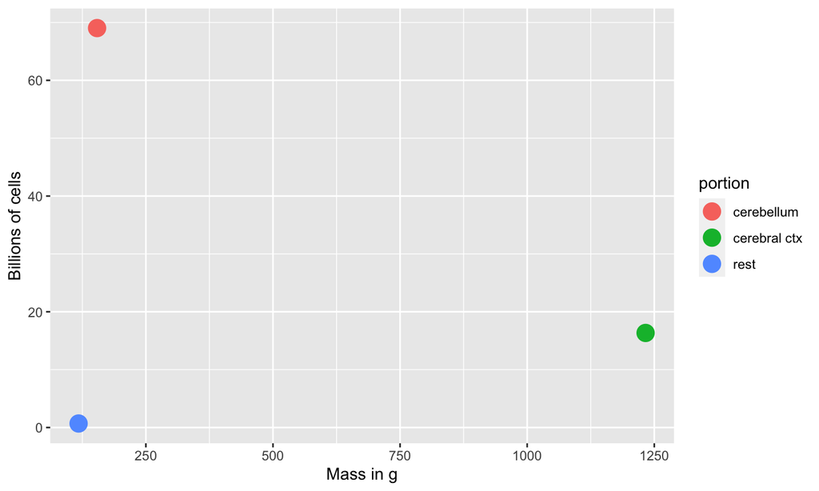

## Non-neuronal cells by brain mass

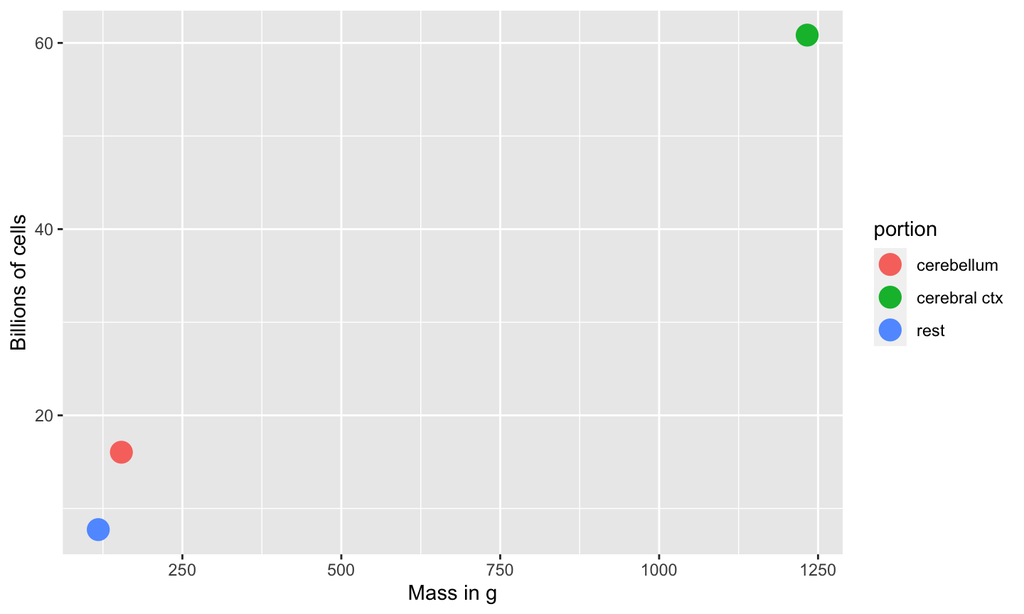

## Summary

## neurons doesn’t scale with brain size/mass (most neurons in cerebellum)

## glia+ cells scales with brain size/mass

## How many neurons and glia?

*“These findings challenge the common view that humans stand out from other primates in their brain composition and indicate that, with regard to numbers of neuronal and nonneuronal cells, the human brain is an isometrically scaled-up primate brain.”*

[(Azevedo et al., 2009)](http://doi.org/10.1002/cne.21974)

## The Human Advantage

[figure not shown]

## Glia (neuroglia)

- “Glia” means glue
- Functions
  - Structural support
  - Metabolic support
  - Brain development
  - Neural plasticity?

## Astrocytes

- “Star-shaped”
- Physical and metabolic support
  - Blood/brain barrier
  - Regulate concentration of key ions (Ca++/K+) for neural communication
  - Regulate concentration of key neurotransmitters (e.g., glutamate)

## Astrocytes

- Shape brain development, [synaptic plasticity](https://en.wikipedia.org/wiki/Synaptic_plasticity)
- Regulate local blood flow (part of fMRI’s blood oxygen-dependent BOLD response)
- Regulate/influence communication between neurons, [(Bazargani & Attwell, 2016)](http://doi.org/10.1038/nn.4201)
- Disruption linked to cognitive impairment, disease [(Chung, Welsh, Barres, & Stevens, 2015)](http://doi.org/10.1038/nn.4142)

## Astrocytes

[figure not shown]

## Myelinating cells

- Produce [myelin](https://en.wikipedia.org/wiki/Myelin) or myelin sheath
  - White, fatty substance
  - Surrounds many neurons
  - The “white” in white matter
- Provide electrical/chemical insulation
- Make neuronal messages faster, less susceptible to noise

## Types of myelin-producing cells

- [Oligodendrocytes](https://en.wikipedia.org/wiki/Oligodendrocyte)
  - In brain and spinal cord (CNS)
  - 1:many neurons
- [Schwann cells](https://en.wikipedia.org/wiki/Schwann_cell)
  - In PNS
  - 1:1 neuron
  - Facilitate neuro-regeneration
- Mnemonics: COPS/SPOC

## Oligodendrocytes

[figure not shown]

## Schwann Cells

[figure not shown]

## Microglia

- Phagocytosis
- Clean-up damaged, dead tissue
- Prune synapses in normal development and disease
- Disruptions in microglia pruning -> impaired functional brain connectivity and social behavior, [(Zhan et al., 2014)](http://doi.org/10.1038/nn.3641)

## Microglia

[figure not shown]

## [Neurons](https://en.wikipedia.org/wiki/Neuron)

[figure not shown]

## Fun facts about [neurons](https://en.wikipedia.org/wiki/Neuron)

- Specialized for electrical & chemical communication
- Post-mitotic – don’t divide
- Most [born early in life](http://www.ninds.nih.gov/disorders/brain_basics/ninds_neuron.htm), [(Bhardwaj et al., 2006)](http://doi.org/10.1073/pnas.0605177103)
- Among longest-lived cells in body, may scale with organism lifespan [(Magrassi, Leto, & Rossi, 2013)](http://doi.org/10.1073/pnas.1217505110)
- Can extend over long distances

## Macrostructure of [neurons](https://en.wikipedia.org/wiki/Neuron)

- [Dendrites](https://en.wikipedia.org/wiki/Dendrite)
- Soma (cell body)
- [Axons](https://en.wikipedia.org/wiki/Axon)
- [Terminal buttons (boutons)](https://en.wikipedia.org/wiki/Axon_terminal)

## Structure of neurons

[figure not shown]

## [Dendrites](https://en.wikipedia.org/wiki/Dendrite)

- Branch-like “extrusions” from cell body
- Majority of input to neuron
- Cluster close to cell body/soma
- Usually receive info
- Passive (do not regenerate electrical signal) vs. active (regenerate signal)
- Spines

## [Dendrites](https://en.wikipedia.org/wiki/Dendrite)

[figure not shown]

## Dendritic Spines

[figure not shown]

## Soma (cell body)

- Varied shapes
- Nucleus
  - Chromosomes
- Organelles
  - Mitochonrdria
  - Smooth and Rough Endoplasmic reticulum (ER)

## Soma

[figure not shown]

## [Axons](https://en.wikipedia.org/wiki/Axon)

- Another branch-like “extrusion” from soma
- Extend farther than dendrites
- Usually transmit info

## [Axons](https://en.wikipedia.org/wiki/Axon)

- Parts
  - **Initial segment** (closest to soma, unmyelinated)
  - **Nodes of Ranvier** (unmyelinated segments along axon)
  - Terminals, axon terminals, terminal buttons, synaptic terminals, synaptic boutons

## Axons

[figure not shown]

## [Synaptic bouton (terminal button)](https://en.wikipedia.org/wiki/Axon_terminal)

- [Synapse](https://en.wikipedia.org/wiki/Chemical_synapse#Structure) (~5-10K per neuron)
- Presynaptic membrane (sending cell) and postsynaptic (receiving cell) membrane
- Synaptic cleft – space between cells
- [Synaptic vesicles](https://en.wikipedia.org/wiki/Synaptic_vesicle)
  - Pouches of neurotransmitters
- [Autoreceptors](https://en.wikipedia.org/wiki/Autoreceptor) (detect NTs); [transporters](https://en.wikipedia.org/wiki/Neurotransmitter_transporter) (transport NTs across membrane)

## [Synaptic bouton (terminal button)](https://en.wikipedia.org/wiki/Axon_terminal)

[figure not shown]

## Classifying neurons

- Functional role
  - Input (sensory), output (motor/secretory), interneurons
- Anatomy
  - Unipolar
  - Bipolar
  - Multipolar

[figure not shown]

https://upload.wikimedia.org/wikipedia/commons/thumb/9/92/Neurons_uni_bi_multi_pseudouni.svg/2000px-Neurons_uni_bi_multi_pseudouni.svg.pngg

## Classifying neurons

- By specific anatomy
  - Pyramidal cells
  - Stellate cells
  - Purkinje cells
  - Granule cells

## Neurons by type

[figure not shown]

## Next time

- How neurons communicate

## References

Azevedo, F. A., Carvalho, L. R., Grinberg, L. T., Farfel, J. M., Ferretti, R. E., Leite, R. E., … others. (2009). Equal numbers of neuronal and nonneuronal cells make the human brain an isometrically scaled-up primate brain. *Journal of Comparative Neurology*, *513*(5), 532–541.

Bazargani, N., & Attwell, D. (2016). Astrocyte calcium signaling: The third wave. *Nature Neuroscience*, *19*(2), 182–189. https://doi.org/10.1038/nn.4201

bbscottvids. (2009, September). Neuronal migration. Youtube. Retrieved from https://www.youtube.com/watch?v=t-8bxeWqSV4

Bhardwaj, R. D., Curtis, M. A., Spalding, K. L., Buchholz, B. A., Fink, D., Björk-Eriksson, T., … Frisén, J. (2006). Neocortical neurogenesis in humans is restricted to development. *Proceedings of the National Academy of Sciences*, *103*(33), 12564–12568. https://doi.org/10.1073/pnas.0605177103

Chung, W.-S., Welsh, C. A., Barres, B. A., & Stevens, B. (2015). Do glia drive synaptic and cognitive impairment in disease? *Nature Neuroscience*, *18*(11), 1539–1545. https://doi.org/10.1038/nn.4142

Magrassi, L., Leto, K., & Rossi, F. (2013). Lifespan of neurons is uncoupled from organismal lifespan. *Proceedings of the National Academy of Sciences*, *110*(11), 4374–4379. https://doi.org/10.1073/pnas.1217505110

Roy, A. L., & Conroy, R. S. (2018). Toward mapping the human body at a cellular resolution. *Molecular Biology of the Cell*, *29*(15), 1779–1785. https://doi.org/10.1091/mbc.E18-04-0260

Zhan, Y., Paolicelli, R. C., Sforazzini, F., Weinhard, L., Bolasco, G., Pagani, F., … Gross, C. T. (2014). Deficient neuron-microglia signaling results in impaired functional brain connectivity and social behavior. *Nature Neuroscience*, *17*(3), 400–406. https://doi.org/10.1038/nn.3641